# 스크립트 프로그래밍 과제 2 (10_17일)

### 문제 1번

- 다음 6 개의 Expression에 대해 Evaluation 결과 값을 출력하고, 해당 결과가 나온 이유에 대해 설명하시오

```python
print (1 and 2 and 3 and 4)    #1
print (1 or 2 or 3 or 4)       #2
print (1 and 2 or 3 and 4)     #3
print ((1 and 2) or (3 and 4)) #4
print (1 or 2 and 3 or 4)      #5
print ((1 or 2) and (3 or 4))  #6
```

```
4
1
2
2
1
3
```

> and 연산은 앞이 false일 경우 앞부분을 반환, true일 경우 뒷부분까지 읽고 반환한다. or 연산은 앞이 true일 경우 앞부분을 반환, false일 경우 뒷부분까지 읽고 반환한다.
> 1. and 앞의 1, 2, 3은 true 이므로 문장의 끝까지 읽고 4를 반환한다.
> 2. 첫 or 앞의 1은 true 이므로 1을 반환하고 종료한다.
> 3. 첫 연산이 and 이므로 1을 지나 2를 읽고, or 연산이고 true 이므로 2반환 후 종료.
> 4. 첫 괄호의 and 연산값은 2, or 연산이고 true 이므로 2를 반환한다.
> 5. 첫 연산은 or 이고 1은 true값 이므로 1 반환 후 종료된다.
> 6. 각 괄호를 계산하면 1, 3이고 and 연산이므로 둘 다 true일 때 뒤가 반환되므로 3이다.

### 문제 2번

- 경로에 해당하는 문자열 1개를 입력 받아 그 안에 디렉토리 경로명과 파일명을 분리하여 리스트로 반환하는 함수 div_path(s)를 작성하시오.
  - 인자로 전달하는 문자열은 경로만 들어간다고 가정한다.
  - 각 디렉토리와 파일을 구분하는 문자는 '/'로 가정한다.
  - 반환하는 리스트의 첫번째 원소는 디렉토리이고 두번째 원소는 파일명이다.
  - 다음과 같은 실행 및 출력 결과가 도출되어야 한다.
    - div_path('/usr/local/bin/python')
      - ['/usr/local/bin', 'python']
    - div_path('/home/chulsoo/test.txt')
      - ['/home/chulsoo', 'test.txt']
  - [참고] 리스트(l) 내에 새로운 정수값 (예를 들어 10)을 넣는 방법은 l.append(10) 이다.

```python
def div_path(s):
    s = (s.split('/'))
    path = ''
    for i in s[1:-1]:
        path += ('/'+i)
    s = [path,s[-1]]
    print (s)
```

```python
div_path('/usr/local/bin/python')
div_path('/home/chulsoo/test.txt')
```

```
['/usr/local/bin', 'python']
['/home/chulsoo', 'test.txt']
```

> 문자열 1개를 입력받아 경로와 파일명을 리스트의 원소로 갖는 div_path() 함수를 정의하였다. 함수의 동작을 단계별로 정리하면
> 1. 원하는 출력을 위해 우선 받은 문자열의 split 메소드를 이용하여 '/'을 기준으로 각 단어들을 나눈 리스트를 생성한다.
> 2. 이를 다시 반복문과 슬라이스 [1:-1]을 사용해 첫번째 원소의 공백과 마지막 원소인 파일명을 제외한 경로 문자열을 만들어 path에 저장한다.
> 3. 그리고 만들어진 경로 문자열과 기존 s의 마지막 원소를 갖는 새로운 리스트 s를 만들어 출력해주는 함수이다.

문제에 나오는 예문들을 넣었을 때 잘 동작하는 것을 확인 할 수 있다.

### 문제 3번

- 두 개의 리스트를 인자로 받아서 그 두 개의 리스트에 대한 '합집합'을 반환하는 함수 list_union(lista, listb)를 작성하시오.
  - 인자로 전달하는 리스트 2 개에는 정수값만 들어간다고 가정하자.
  - 함수 내에서 새로운 리스트를 만들어 그 리스트 내에 인자로 받은 두 리스트의 모든 원소를 넣어 반환한다.
  - 반환하는 리스트에는 절대로 중복된 원소가 들어 있으면 안된다 (집합의 조건).
  - 반환하는 리스트는 정렬이 되어 있어야 한다.
  - 다음과 같은 실행 및 출력 결과가 도출되어야 한다.
    - list_union([1, 2, 3], [1, 2, 4])
      - [1, 2, 3, 4]
    - list_union([-10, -5, 0, -1], [100, 9, 0, 9])
      - [-10, -5, -1, 0, 9, 100]
    - list_union([0, 1, 2], [0, 1, 2])
      - [0, 1, 2]
  - [참고] 리스트(l) 내에 새로운 정수값 (예를 들어 10)을 넣는 방법은 l.append(10) 이다.
  - [참고] 임의의 정수값 (x)이 리스트 (l) 내에 존재하는지 판단하는 방법은 x in l 이다.

```python
def list_union(lista,listb):
    for i in range(len(listb)):
        if(listb[i] in lista):
            continue
        else:
            lista.append(listb[i])
    lista.sort()
    print (lista)
```

```python
list_union([1, 2, 3], [1, 2, 4])
list_union([-10, -5, 0, -1], [100, 9, 0, 9])
list_union([0, 1, 2], [0, 1, 2])
```

```
[1, 2, 3, 4]
[-10, -5, -1, 0, 9, 100]
[0, 1, 2]
```

> 정수로 이루어진 리스트 두개를 받아 정렬된 합집합 리스트를 출력하는 list_union() 함수를 정의하였다. 이를 단계별로 정리하면
> 1. listb의 원소 갯수만큼 반복하는 for문을 열어주고
> 2. 멤버십 테스트를 통해 i번째 listb 원소가 lista에 존재하는지 확인한다.
> 3. 존재할경우 다음 반복으로 continue, 없는 원소일 경우 lista에 추가해준다.
> 4. 마지막으로 합쳐진 lista 를 sort()메소드로 정렬하고 출력한다.

예시로 나온 예문을 넣었을때 잘 동작하는 것을 확인 할 수 있다.

### 문제 4번 :ACM-ICPC 문제 1110번

- 0보다 크거나 같고, 99보다 작거나 같은 정수가 주어질 때 다음과 같은 연산을 할 수 있다. 먼저 주어진 수가 10보다 작다면 앞에 0을 붙여 두 자리 수로 만들고, 각 자리의 숫자를 더한다. 그 다음, 주어진 수의 가장 오른쪽 자리 숫자와 앞에서 구한 합의 가장 오른쪽 자리 숫자를 이어 붙이면 새로운 수를 만들 수 있다. 다음 예를 보자.
  - 26부터 시작한다. 2+6 = 8이다. 새로운 숫자는 68이다. 6+8 = 14이다. 새로운 숫자는 84이다. 8+4 = 12이다. 새로운 숫자는 42이다. 4+2 = 6이다. 새로운 숫자는 26이다.
    - 위의 예는 4번만에 원래 숫자로 돌아올 수 있다. 따라서 26의 사이클의 길이는 4이다.

N이 주어졌을 때, N의 사이클의 길이를 구하는 프로그램을 작성하시오.

```python
N = int(input())
if (N<10):
    N *=10
stat = N
count = 0
while(True):
    count +=1
    nextStat = int(((stat%10)*10)+(((stat/10)+(stat%10))%10))
    if (nextStat == N):
        print (count)
        break
    else:
        stat = nextStat
```

```
26
4
```

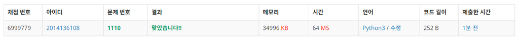

```python
from IPython.display import Image
Image(filename='correct.PNG')
```

> 프로그램의 진행을 순서대로 정리하면

> ```
> 1. 입력받은 수를 이용해 두 자리 수 N을 만든다.
> 2. N을 stat 변수에 대입하고 stat의 첫째 자리 수와 각 자리의 숫자를 더한 값의 첫째 자리 수를 이어 붙여 새로운 변수 nextStat을 만들어 준다.
> 3. nextStat이 첫 입력값 N과 일치하는지 확인한다.
> 4. 일치하면 반복문이 돈 횟수 count를 출력하고 종료한다.
> 5. 불일치하면 nextStat을 stat에 대입하고 계속 반복한다.
> ```

- 이는 N과 일치할 때 까지 nextStat을 만들고, 이를 stat으로 대입하며 반복되는 프로그램이다.
  - 예시로 나온 '26'을 입력했을때 정상적으로 동작하는것을 확인하였다.

### 문제 5번 : [Incremental Project]

- 웹 URL로 지정된 웹페이지를 문자열로 가져와 1) 모든 HTML 태그를 제외한 순수 텍스트 문자열만을 걸러내고, 2) 그 순수 텍스트 문자열 안에 존재하는 단어가 총 몇개인지 출력하는 프로그램을 작성하시오.

```python
from urllib import request

url = 'http://cse.koreatech.ac.kr'
f = request.urlopen(url)
source_bytes = f.read()
source = source_bytes.decode('utf-8')

# 추후 숙제 답안 제출 때엔 아래 코드는 주석처리할 것
    #print(type(source_bytes))
    #print(type(source))
    #print(source)
```

```python
# 소스 문자열의 순수 텍스트 문자열을 걸러내고 단어의 개수를 출력하는 프로그램
state = 1
pull = ''
for i in range(len(source)):
    if (source[i] == '<'):
        state = -1
        continue
    if(source[i] == '>'):
        state = 1
        continue
    if (state == 1):
        pull += source[i]


print ("source의 순수 문자 갯수는 :" + str(len(pull.split())))
```

```
source의 순수 문자 갯수는 :464
```

> 위 프로그램의 실행 과정을 순서대로 정리하면
> 1. 문자의 위치가 HTML 태그에 있는지 확인하기 위해 state 변수를 생성한다.
> 2. 순수 문자열이 입력될 pull 변수를 생성하고 빈 문자열로 초기화한다.
> 3. source의 길이만큼 반복하는 for문을 생성하고 0번째 문자부터 하나씩 읽어간다.
> 4. 읽은 문자가 태그의 시작을 의미하는 < 이면 state를 -1로 바꾸고 continue.
> 5. 읽은 문자가 태그의 종료를 의미하는 > 이면 state를 1로 바꾸고 continue.
> 6. state가 1이고 '<','>' 문자가 아닐경우 pull 문자열에 해당 문자를 추가한다.
> 7. pull의 메소드 split()을 이용해 공백을 제거하고 이를 다시 len()으로 읽어 원소의 개수, 즉 단어의 총 개수를 구하여 출력한다.
- pull.split() 을 출력해 확인해보면 정상적으로 문자들이 추출된 것을 확인 할 수 있다.

## 과제 이후 소감

이번에는 문제의 양도 적고 처음 markdown 문법을 사용할때 느끼던 막막함이 없어 좀 더 수월하게 과제를 끝낸 것 같다.  
하지만 단순해 보이는 코드에 비해 파이썬에서 제공하는 다양한 메소드 함수를 사용하기 위해 생각보다 많은 시간이 걸렸던 것 같다.  
강의노트를 참고해가며 하나씩 프로그램을 만들다 보니 기본적인 메소드를 완전히 익히고 자연스럽게 사용하기 위해서는 더욱 많은 노력이 필요하겠다는 생각이 든다.